# Análise preliminar

Francisco d’Albertas & Patricia Ruggiero

21/09/2021

## Objetivos

Depois de ter excecutado matching, analisar a efetividade da certificação usando análise de regressão em painel.

A idéia é Analisar os dados com a área das propriedades em log e na escala original (variáveis usadas para realizar o matching).

Os modelos foram construídos de duas formas:

- através de uma abordagem bayesiana, que segue a lógica formal dos modelos que a gente usa na ecologia (usei como referência os scripts do artigo *GLMM BACI environmental impact analysis shows coastal dune restoration reduces seed predation on an endangered plant, de Pardini et al., 2018.*.
- Modelo da econometria

## Desmatamento

Calculei a taxa de desmatamento como a área desmatada em um dado ano dividida pela área de floresta no respectivo ano. Usar a área do ano anterior gera uma série de erros (**discutir isso**)

Como eu não consigo graficar os resultados do modelo econométrico, os dados brutos plotados podem ser usados para ilustrar o problema:

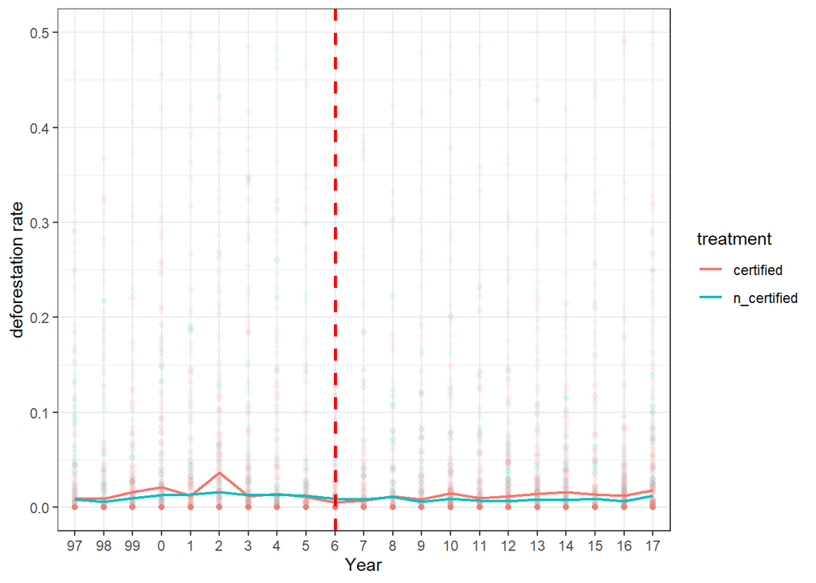

### Modelando os dados como “ecólogos fariam”

```r
library(INLA)

# documentação da função
#names(inla.models()$likelihood)
#inla.doc("familyname")

# deu certo!

# m01 <- inla(y~certification*treatment+f(COD_IMOVEL,model = "iid")+f(year,model = "iid"),
#   family = "beta",
#   data = desm,
#   control.predictor = list(link = 1),
#   verbose=TRUE
# )


summary(m01)
```

```
##
## Call:
##    c("inla(formula = y ~ certification * treatment + f(COD_IMOVEL, ", " model = \"iid\") + f(year,
##    model = \"iid\"), family = \"beta\", ", " data = desm, verbose = TRUE, control.predictor =
##    list(link = 1))" )
## Time used:
##     Pre = 0.55, Running = 44.3, Post = 1.59, Total = 46.5
## Fixed effects:
##                                           mean    sd 0.025quant 0.5quant 0.975quant   mode kld
## (Intercept)                             -3.889 0.019     -3.927   -3.889     -3.851 -3.890   0
## certificationafter                       0.014 0.020     -0.025    0.014      0.052  0.014   0
## treatmentn_certified                    -0.054 0.019     -0.091   -0.054     -0.018 -0.054   0
## certificationafter:treatmentn_certified -0.015 0.027     -0.068   -0.015      0.038 -0.015   0
##
## Random effects:
##   Name     Model
##     COD_IMOVEL IID model
##    year IID model
##
## Model hyperparameters:
##                                                   mean       sd 0.025quant 0.5quant 0.975quant     mode
## precision parameter for the beta observations     6.64 1.22e-01       6.40     6.64   6.89e+00     6.64
## Precision for COD_IMOVEL                      48427.91 2.44e+04   15903.01 43623.44   1.09e+05 34653.13
## Precision for year                            13978.40 1.01e+04    2714.12 11452.52   4.03e+04  7058.10
##
## Expected number of effective parameters(stdev): 6.37(1.23)
## Number of equivalent replicates : 3493.31
##
## Marginal log-Likelihood:  149901.08
## Posterior marginals for the linear predictor and
##  the fitted values are computed
```

Plotando o tamanho do efeito:

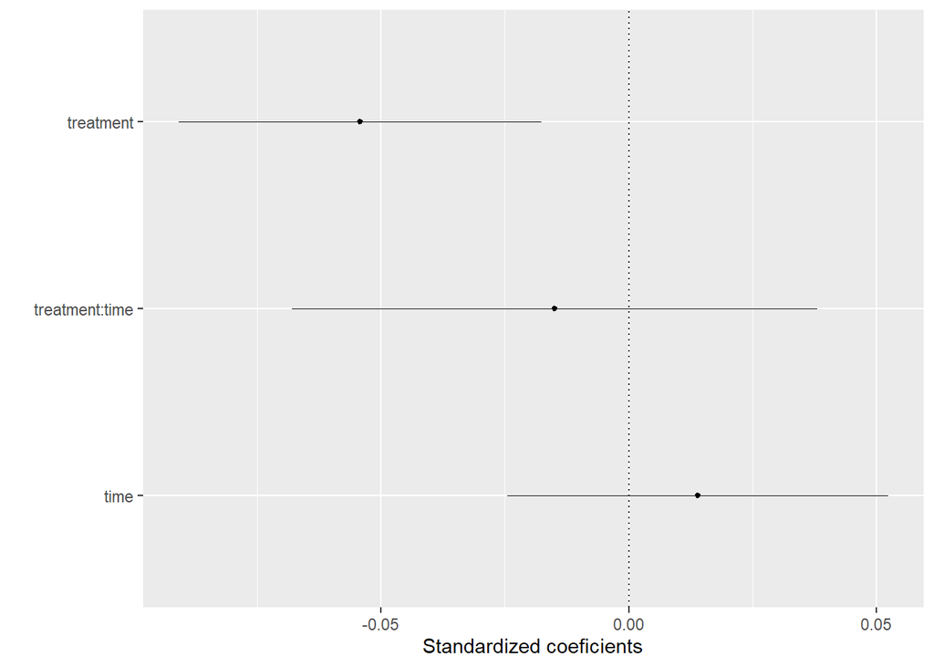

### Modelando os dados usando modelo econométrico

```r
library(plm)

m02 <- plm(formula = y ~ treatment*certification, data = desm, effect="individual",model = "within", index = c("COD_IMOVEL","year"))

summary(m02)
```

```
## Oneway (individual) effect Within Model
##
## Call:
## plm(formula = y ~ treatment * certification, data = desm, effect = "individual",
##     model = "within", index = c("COD_IMOVEL", "year"))
##
## Balanced Panel: n = 1060, T = 21, N = 22260
##
## Residuals:
##        Min.     1st Qu.      Median     3rd Qu.        Max.
## -0.10849905 -0.01283051 -0.00130918  0.00056654  0.95377826
##
## Coefficients:
##                                           Estimate Std. Error t-value Pr(>|t|)
## certificationafter                      -0.0010816  0.0012107 -0.8933   0.3717
## treatmentn_certified:certificationafter -0.0016677  0.0017122 -0.9740   0.3301
##
## Total Sum of Squares:    86.289
## Residual Sum of Squares: 86.265
## R-Squared:      0.00028082
## Adj. R-Squared: -0.049757
## F-statistic: 2.97721 on 2 and 21198 DF, p-value: 0.050956
```

```r
library(clubSandwich)

m02c <- coef_test(m02, vcovCR(m02, cluster = desm$COD_IMOVEL, type = "CR1S"))

m02c
```

```
##                                     Coef. Estimate      SE t-stat d.f. p-val (Satt) Sig.
## 1                      certificationafter -0.00108 0.00127 -0.851  529        0.395
## 2 treatmentn_certified:certificationafter -0.00167 0.00174 -0.959 1058        0.338
```

Plotando o tamanho do efeito:

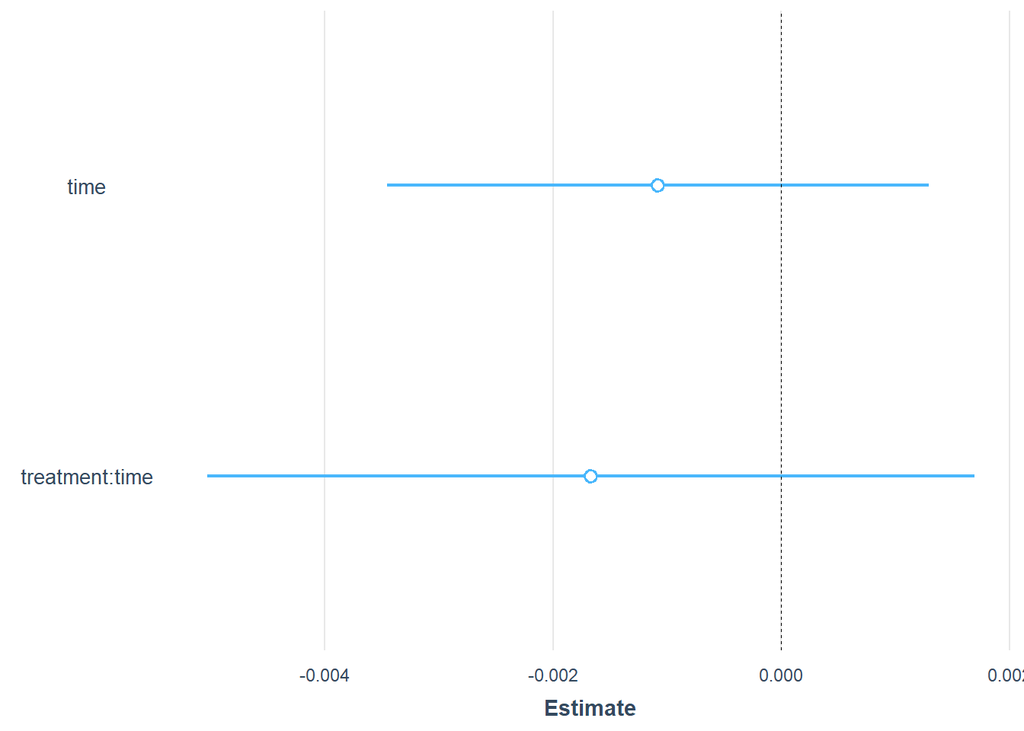